# Personal activity classification project

## Description

Using devices such as Jawbone Up, Nike FuelBand, and Fitbit it is now possible to collect a large amount of data about personal activity relatively inexpensively. These type of devices are part of the quantified self movement – a group of enthusiasts who take measurements about themselves regularly to improve their health, to find patterns in their behavior, or because they are tech geeks. One thing that people regularly do is quantify how much of a particular activity they do, but they rarely quantify how well they do it. In this project, the goal will be to use data from accelerometers on the belt, forearm, arm, and dumbell of 6 participants and predict the manner in which people did the exercise. This is the “classe” variable in the training set.

## Data

The training data for this project are available here: https://d396qusza40orc.cloudfront.net/predmachlearn/pml-training.csv

The test data are available here: https://d396qusza40orc.cloudfront.net/predmachlearn/pml-testing.csv

## Data preprocess

```r
library(caret)
trainingDS <- read.csv("pml-training.csv", stringsAsFactors = F)
trainingDS$classe <- as.factor(trainingDS$classe)

testingDS <- read.csv("pml-testing.csv", stringsAsFactors = F)

dim(trainingDS)
```

```
## [1] 19622   160
```

Lets explore the data

```r
str(trainingDS)
```

```
## 'data.frame':    19622 obs. of  160 variables:
##  $ X                       : int  1 2 3 4 5 6 7 8 9 10 ...
##  $ user_name               : chr  "carlitos" "carlitos" "carlitos" "carlitos" ...
##  $ raw_timestamp_part_1    : int  1323084231 1323084231 1323084231 1323084232 1323084232 1323084232 1323084232 1323084232 1323084232 1323084232 ...
##  $ raw_timestamp_part_2    : int  788290 808298 820366 120339 196328 304277 368296 440390 484323 484434 ...
##  $ cvtd_timestamp          : chr  "05/12/2011 11:23" "05/12/2011 11:23" "05/12/2011 11:23" "05/12/2011 11:23" ...
##  $ new_window              : chr  "no" "no" "no" "no" ...
##  $ num_window              : int  11 11 11 12 12 12 12 12 12 12 ...
##  $ roll_belt               : num  1.41 1.41 1.42 1.48 1.48 1.45 1.42 1.42 1.43 1.45 ...
##  $ pitch_belt              : num  8.07 8.07 8.07 8.05 8.07 8.06 8.09 8.13 8.16 8.17 ...
##  $ yaw_belt                : num  -94.4 -94.4 -94.4 -94.4 -94.4 -94.4 -94.4 -94.4 -94.4 -94.4 ...
##  $ total_accel_belt        : int  3 3 3 3 3 3 3 3 3 3 ...
##  $ kurtosis_roll_belt      : chr  "" "" "" "" ...
##  $ kurtosis_picth_belt     : chr  "" "" "" "" ...
##  $ kurtosis_yaw_belt       : chr  "" "" "" "" ...
```

[output cut: 86 more lines]

As we can see, there are a lot of null values. Let’s look at them a little bit closer. I will count all the null values and empty string by column, and put this values in *emptyVals* vector

```r
emptyVals <- c()
cnames = colnames(trainingDS)
for (n in 1:length(cnames)){emptyVals <- c(emptyVals, sum((is.na(trainingDS[ ,n]) | trainingDS[ ,n]=="")))}
emptyVals[emptyVals!=0]
```

```
##   [1] 19216 19216 19216 19216 19216 19216 19216 19216 19216 19216 19216
##  [12] 19216 19216 19216 19216 19216 19216 19216 19216 19216 19216 19216
##  [23] 19216 19216 19216 19216 19216 19216 19216 19216 19216 19216 19216
##  [34] 19216 19216 19216 19216 19216 19216 19216 19216 19216 19216 19216
##  [45] 19216 19216 19216 19216 19216 19216 19216 19216 19216 19216 19216
##  [56] 19216 19216 19216 19216 19216 19216 19216 19216 19216 19216 19216
##  [67] 19216 19216 19216 19216 19216 19216 19216 19216 19216 19216 19216
##  [78] 19216 19216 19216 19216 19216 19216 19216 19216 19216 19216 19216
##  [89] 19216 19216 19216 19216 19216 19216 19216 19216 19216 19216 19216
## [100] 19216
```

Looks like the number of columns has no meaning values at all. All the predictors, containing less then 5% of meaning values will be excluded from the model. Also exclude timing predictors, user name and training variable X also will be excluded

```r
perc95 <- dim(trainingDS)[1]*0.95
lessperc5 <- emptyVals > perc95
trainingDS1 <- subset(trainingDS, select=c(lessperc5 == 0))

trainingDS1 <- subset(trainingDS1, select=-c(user_name, cvtd_timestamp, raw_timestamp_part_2, raw_timestamp_part_1, new_window, num_window, X))

dim(trainingDS1)
```

```
## [1] 19622    53
```

```r
anyNA(trainingDS1)
```

```
## [1] FALSE
```

No missed values in training dataset

## Building a model

### Knn model

```r
set.seed(12321)
inTrain <- createDataPartition(y=trainingDS1$classe, p=0.7, list=F)
training <- trainingDS1[inTrain,]
validating <- trainingDS1[-inTrain,]
trctrl <- trainControl(method = "repeatedcv", number = 10, repeats = 3)
knn_fit <- train(classe ~., data = training, method = "knn",
                 trControl=trctrl,
                 preProcess = c("center", "scale"),
                 tuneLength = 10)
pred_knn <- predict(knn_fit, validating)
knn_acc <- confusionMatrix(pred_knn, validating$classe)$overall[1]
knn_acc
```

```
##  Accuracy
## 0.9651657
```

### SVM model

```r
set.seed(12321)
svm_fit <- train(classe ~., data = training, method = "svmLinear")
pred_svm <- predict(svm_fit, validating)
svm_acc <- confusionMatrix(pred_svm, validating$classe)$overall[1]
svm_acc
```

```
##  Accuracy
## 0.7833475
```

### RF Model

RF model was built just at 10% of the data

```r
set.seed(12321)
inTrainRF <- createDataPartition(y=trainingDS1$classe, p=0.1, list=F)
trainingRF <- trainingDS1[inTrainRF,]
validatingRF <- trainingDS1[-inTrainRF,]

rf_fit <- train(classe~., data=trainingRF, method='rf')
pred_rf <- predict(rf_fit, validatingRF)
rf_acc <- confusionMatrix(pred_rf, validatingRF$classe)$overall[1]
rf_acc
```

```
##  Accuracy
## 0.9514101
```

## Results

I checked 3 models: KNN model, SVM Linear model and Random Forest. It is not correct to compare results, because this algorithms were run on the different training sets (70% for KNN and SVM and just 10% for RF), but inspite of this disballance, RF demotstrated very good accuracy on much bigger validation set.

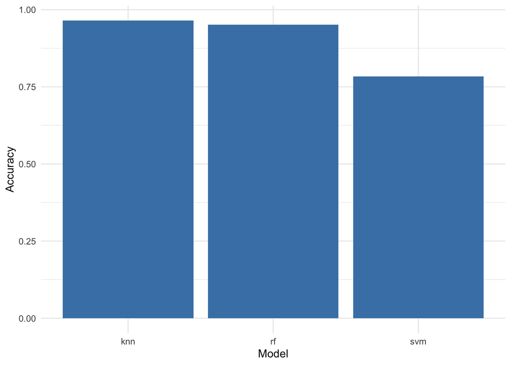

```r
acc_df <- data.frame("Model"=c("knn", "svm", "rf"),
                     "Accuracy"=c(as.numeric(knn_acc),as.numeric(svm_acc), as.numeric(rf_acc)))
p <- ggplot(data=acc_df, aes(x=Model, y=Accuracy)) +
   geom_bar(stat="identity", fill="steelblue")+
   theme_minimal()
p
```

## Test prediction

Predicted values with RF model

```r
predict(rf_fit, testingDS)
```

```
##  [1] B A B A A E D B A A C C B A E E A D B B
## Levels: A B C D E
```